# Simulation Study: Clustering Performance with Decreasing Cluster Separation (Enhanced with COCA)

2025-07-27

# Executive Summary

This simulation study investigates how well we can recover known clustering structures as the separation between clusters decreases. We generate synthetic datasets with two independent clustering structures and test whether our **complete analysis pipeline** (including COCA consensus clustering) can correctly identify and separate these structures.

**Key Question**: At what point does cluster overlap become so severe that we can no longer distinguish between different clustering structures, and how does COCA consensus clustering perform across this range?

# 1. Methods

## 1.1 Data Generation

We generate synthetic 10-dimensional datasets with two independent clustering structures:

- **Structure 1**: 3 clusters present in dimensions 1-5
- **Structure 2**: 4 clusters present in dimensions 6-10

The key experimental manipulation is the **separation factor**, which controls how far apart the clusters are. We test 10 separation levels from highly separable (6σ) to highly overlapping (0.5σ).

## 1.2 Complete Analysis Pipeline

For each dataset, we now run the **full 5-step pipeline**:

1. Apply MCLUST to each dimension independently to detect the number of clusters
2. Compute pairwise Adjusted Rand Index (ARI) between all dimension-wise clusterings
3. Use HClust clustering on the ARI dissimilarity matrix to group dimensions with similar clustering patterns
4. Evaluate whether HClust correctly separates dimensions 1-5 from dimensions 6-10
5. **NEW**: Apply COCA consensus clustering to each discovered dimension group

# 2. Implementation

```r
# Load required libraries
library(mvtnorm)      # For multivariate normal data generation
library(cluster)      # For PAM clustering
library(mclust)       # For model-based clustering
library(coca)         # For consensus clustering
library(ggplot2)      # For visualization
library(dplyr)        # For data manipulation
library(tidyr)        # For data reshaping
library(gridExtra)    # For arranging plots

# Set seed for reproducibility
set.seed(42)
```

```r
# Set up caching directory
cache_dir <- "simulation_cache"
if (!dir.exists(cache_dir)) {
  dir.create(cache_dir)
  cat("Created cache directory:", cache_dir, "\n")
}

# Define cache file names
results_cache_file <- file.path(cache_dir, "simulation_results.rds")
detailed_cache_file <- file.path(cache_dir, "detailed_results.rds")
coca_cache_file <- file.path(cache_dir, "coca_results.rds")
metadata_file <- file.path(cache_dir, "simulation_metadata.rds")

# Function to check if cache is valid
check_cache_validity <- function(current_params) {
  if (!file.exists(metadata_file)) {
    return(FALSE)
  }

  cached_params <- readRDS(metadata_file)

  # Check if all parameters match
  params_match <- all(
    cached_params$n_samples == current_params$n_samples,
    cached_params$n_replications == current_params$n_replications,
    identical(cached_params$separation_factors, current_params$separation_factors),
    cached_params$cluster_variance == current_params$cluster_variance,
    identical(cached_params$cluster_props_1, current_params$cluster_props_1),
    identical(cached_params$cluster_props_2, current_params$cluster_props_2),
    cached_params$random_seed == current_params$random_seed
  )

  return(params_match)
}
```

```r
# Simulation parameters
n_samples <- 500              # Number of observations per dataset
n_replications <- 25          # Number of replications per separation level

# Clustering structures
n_clusters_1 <- 3             # Number of clusters in Structure 1
n_clusters_2 <- 4             # Number of clusters in Structure 2
cluster_props_1 <- c(0.4, 0.35, 0.25)      # Cluster proportions for Structure 1
cluster_props_2 <- c(0.3, 0.25, 0.25, 0.2) # Cluster proportions for Structure 2

# Fixed within-cluster variance
cluster_variance <- 0.3

# Separation factors to test (from highly separable to highly overlapping)
separation_factors <- c(6.0, 4.5, 3.0, 2.5, 2.0, 1.5, 1.2, 1.0, 0.8, 0.5)

# Ground truth structure labels for dimensions
true_structure_labels <- c(rep(1, 5), rep(2, 5))  # 1 for Structure 1, 2 for Structure 2

# Store current parameters for cache validation
current_params <- list(
  n_samples = n_samples,
  n_replications = n_replications,
  separation_factors = separation_factors,
  cluster_variance = cluster_variance,
  cluster_props_1 = cluster_props_1,
  cluster_props_2 = cluster_props_2,
  random_seed = 42
)
```

```r
# Define fixed version of consensusCluster for reproducibility
consensusClusterPDWK <- function (data = NULL, K = 2, B = 100, pItem = 0.8, clMethod = "hclust",
          dist = "euclidean", hclustMethod = "complete", sparseKmeansPenalty = NULL,
          maxIterKM = 1000)
{
  # Set seed for reproducibility within this function
  set.seed(42)

  containsFactors <- 0
  if (!is.null(data)) {
    N <- dim(data)[1]
    P <- dim(data)[2]
    for (i in seq_len(P)) {
      containsFactors <- as.numeric(is.factor(data[, i])) +
        containsFactors
    }
  }
  else if (is.double(dist)) {
    N <- dim(dist)[1]
  }
  else {
    stop("If the data matrix is not provided, `dist` must be a symmetric\n        matrix of type double providing the distances between each pair of\n        observations.")
  }
  dataIndices <- seq_len(N)
  coClusteringMatrix <- indicatorMatrix <- matrix(0, N, N)
  for (b in seq_len(B)) {
    # Set seed for each iteration to ensure reproducibility
    set.seed(42 + b)

    items <- sample(N, ceiling(N * pItem), replace = FALSE)
    nUniqueDataPoints <- 0
    if (!is.null(data)) {
      uniqueData <- unique(data[items, ])
      nUniqueDataPoints <- nrow(uniqueData)
    }
    if (nUniqueDataPoints >= K | is.null(data)) {
      if (clMethod == "pam" | containsFactors) {
        if (is.double(dist) & isSymmetric(dist)) {
          distances <- stats::as.dist(dist[items, items])
        }
        else if (dist == "cor") {
          distances <- stats::as.dist(1 - stats::cor(t(data[items,
          ])))
        }
        else if (dist == "binary") {
          distances <- stats::dist(data[items, ], method = dist)
        }
        else if (dist == "gower") {
          distances <- cluster::daisy(data[items, ],
                                      metric = "gower")
        }
        else {
          stop("Distance not recognized. If method is `pam`, distance\n                must be one of `cor`, `binary`, `gower` or the symmetric\n                matrix of distances.")
        }
        cl <- cluster::pam(distances, K)$clustering
      }
      else if (clMethod == "kmeans" & !is.null(data)) {
        cl <- stats::kmeans(data[items, ], K, iter.max = maxIterKM,
                            nstart = 20)$cluster
      }
      else if (clMethod == "sparse-kmeans" & !is.null(data)) {
        if (is.null(sparseKmeansPenalty))
          sparseKmeansPenalty = sqrt(P)
        cat("sparseKmeansPenalty", sparseKmeansPenalty,
            "\n")
        cl <- sparcl::KMeansSparseCluster(data[items,
        ], K, wbounds = sparseKmeansPenalty)[[1]]$Cs
      }
      else if (clMethod == "hclust" | clMethod == "sparse-hclust") {
        if (dist == "pearson" | dist == "spearman") {
          pearsonCor <- stats::cor(t(data[items, ]),
                                   method = dist)
          distances <- stats::as.dist(1 - pearsonCor)
        }
        else if (is.double(dist)) {
          distances <- stats::as.dist(dist[items, items])
        }
        else {
          distances <- stats::dist(data[items, ], method = dist)
        }
        if (clMethod == "hclust") {
          hClustering <- stats::hclust(distances, method = hclustMethod)
        }
        else {
          hClustering <- sparcl::HierarchicalSparseCluster(dists = as.matrix(distances),
                                                           method = "average", wbound = 10)$hc
        }
        cl <- stats::cutree(hClustering, K)
      }
      else {
        stop("Clustering algorithm name not recognised. Please choose\n                     one of `kmeans`, `hclust`, `pam`, `sparse-kmeans`,\n                     `sparse-hclust`.")
      }
      indicatorMatrix <- indicatorMatrix + crossprod(t(as.numeric(dataIndices %in%
                                                                    items)))
      for (k in seq_len(K)) {
        coClusteringMatrix[items, items] <- coClusteringMatrix[items,
                                                               items] + crossprod(t(as.numeric(cl == k)))
      }
    }
  }
  if (!sum(indicatorMatrix) == 0) {
    consensusMatrix <- coClusteringMatrix/indicatorMatrix
  }
  else {
    consensusMatrix <- indicatorMatrix
    warning(paste("Consensus matrix is empty for K =", K,
                  "because there are\n                      less than",
                  K, "distinct data points", sep = ""))
  }
  return(consensusMatrix)
}

# Save original function and replace with fixed version
consensusClusterOriginal <- coca::consensusCluster
assignInNamespace("consensusCluster", consensusClusterPDWK, ns="coca")
```

```r
# Function to generate cluster means based on separation factor
generate_cluster_means <- function(separation_factor, cluster_variance) {
  base_separation <- separation_factor * sqrt(cluster_variance)

  # Structure 1 means (3 clusters, dims 1-5)
  means_1 <- list(
    cluster_1 = c(-1, -1.3, -1.2, -1.5, -1.1) * base_separation,
    cluster_2 = c(1, 1.3, 1.2, 1.5, 1.1) * base_separation,
    cluster_3 = c(0, 0, 0, 0, 0)
  )

  # Structure 2 means (4 clusters, dims 6-10)
  means_2 <- list(
    cluster_1 = c(-1.3, -1, -1.25, -1.4, -1.2) * base_separation,
    cluster_2 = c(1.3, 1, 1.25, 1.4, 1.2) * base_separation,
    cluster_3 = c(-0.3, 0.3, -0.4, 0.4, -0.25) * base_separation,
    cluster_4 = c(0.3, -0.3, 0.4, -0.4, 0.25) * base_separation
  )

  return(list(means_1 = means_1, means_2 = means_2))
}

# Function to generate one dataset (deterministic with known seed)
generate_dataset_with_seed <- function(separation_factor, cluster_variance, n_samples,
                                     cluster_props_1, cluster_props_2, seed_offset = 0) {

  # Set seed for reproducible generation
  set.seed(42 + seed_offset)

  # Generate cluster assignments
  cluster_1_assignments <- sample(1:n_clusters_1, n_samples,
                                 replace = TRUE, prob = cluster_props_1)
  cluster_2_assignments <- sample(1:n_clusters_2, n_samples,
                                 replace = TRUE, prob = cluster_props_2)

  # Get cluster means
  means_list <- generate_cluster_means(separation_factor, cluster_variance)
  means_1 <- means_list$means_1
  means_2 <- means_list$means_2

  # Define covariance matrices (spherical clusters)
  covs_1 <- list(
    cluster_1 = diag(rep(cluster_variance, 5)),
    cluster_2 = diag(rep(cluster_variance, 5)),
    cluster_3 = diag(rep(cluster_variance, 5))
  )

  covs_2 <- list(
    cluster_1 = diag(rep(cluster_variance, 5)),
    cluster_2 = diag(rep(cluster_variance, 5)),
    cluster_3 = diag(rep(cluster_variance, 5)),
    cluster_4 = diag(rep(cluster_variance, 5))
  )

  # Initialize data matrix
  data_matrix <- matrix(NA, nrow = n_samples, ncol = 10)

  # Generate data for Structure 1 (dimensions 1-5)
  for (i in 1:n_samples) {
    cluster_id <- cluster_1_assignments[i]
    data_matrix[i, 1:5] <- rmvnorm(1,
                                  mean = means_1[[cluster_id]],
                                  sigma = covs_1[[cluster_id]])
  }

  # Generate data for Structure 2 (dimensions 6-10)
  for (i in 1:n_samples) {
    cluster_id <- cluster_2_assignments[i]
    data_matrix[i, 6:10] <- rmvnorm(1,
                                   mean = means_2[[cluster_id]],
                                   sigma = covs_2[[cluster_id]])
  }

  return(list(
    data = data_matrix,
    true_labels_1 = cluster_1_assignments,
    true_labels_2 = cluster_2_assignments
  ))
}
```

```r
# Function to analyze one dataset (original analysis without COCA)
analyze_dataset <- function(data_matrix) {
  n_dims <- ncol(data_matrix)

  # Step 1: MCLUST on each dimension
  mclust_results <- list()
  cluster_assignments <- matrix(NA, nrow = nrow(data_matrix), ncol = n_dims)

  for(i in 1:n_dims) {
    mclust_fit <- Mclust(data_matrix[, i], G = 1:9, verbose = FALSE)
    mclust_results[[i]] <- mclust_fit
    cluster_assignments[, i] <- mclust_fit$classification
  }

  # Step 2: Compute ARI matrix between all dimension pairs
  ari_matrix <- matrix(NA, nrow = n_dims, ncol = n_dims)
  for(i in 1:n_dims) {
    for(j in 1:n_dims) {
      if(i == j) {
        ari_matrix[i, j] <- 1.0
      } else {
        ari_matrix[i, j] <- adjustedRandIndex(cluster_assignments[, i],
                                              cluster_assignments[, j])
      }
    }
  }

  # Step 3: HClust clustering on ARI dissimilarity
  dissim_matrix <- 1 - ari_matrix
  diag(dissim_matrix) <- 0
  dissim_dist <- as.dist(dissim_matrix)

  # Test different numbers of clusters
  opt <- NbClust::NbClust(diss = dissim_dist, distance = NULL,
                        min.nc = 2, max.nc = 6, method = "complete",
                        index = "dunn")

  if (opt$Best.nc[2] == Inf) {

    index <- "silhouette"

    cat(sprintf("Optimal Number of Clusters:\n k = %d: Dunn Index = %.3f\n",
                  opt$Best.nc[1], opt$Best.nc[2]))
    cat("\nInfinite Dunn Index -> Switching to Silhouette Index\n")

    k_values <- 2:6
    index_values <- numeric(length(k_values))
    hclust_results <- list()

    for(i in seq_along(k_values)) {
      k <- k_values[i]
      hclust_fit <- hclust(dissim_dist, method = "complete")
      clusters <- cutree(hclust_fit, k = k)
      hclust_results[[as.character(k)]] <- clusters
      index_values[i] <- mean(silhouette(clusters, dist = dissim_dist)[, "sil_width"])

      cat(sprintf("\n k = %d: Average silhouette width = %.3f",
                  k, silhouette_widths[i]))
    }

    # Find optimal number of clusters
    optimal_idx <- which.max(index_values)
    optimal_k <- k_values[optimal_idx]
    optimal_hclust <- hclust_results[[optimal_idx]]

    cat("\nOptimal number of dimension groups:", optimal_k, "\n")

  } else {

    index = "dunn"

    for (i in 1:length(opt$All.Index)) {

      k <- names(opt$All.index)[i]
      val <- opt$All.index[[i]]
      cat(sprintf("k = %s: Dunn Index = %.3f\n",
                  k, val))

    }

    index_values <- as.numeric(opt$All.index)

    # Find optimal number of clusters
    optimal_idx <- opt$Best.nc
    optimal_k <- opt$Best.nc[1]
    optimal_hclust <- opt$Best.partition

  }

  # Step 4: Calculate recovery ARI
  recovery_ari <- adjustedRandIndex(optimal_hclust, true_structure_labels)

  # Additional metrics
  detected_clusters <- sapply(mclust_results, function(x) x$G)

  return(list(
    recovery_ari = recovery_ari,
    optimal_k = optimal_k,
    index = index,
    index_value = index_values,
    detected_clusters = detected_clusters,
    hclust_clustering = optimal_hclust,
    cluster_assignments = cluster_assignments,
    mclust_results = mclust_results
  ))
}

# NEW: Function to add COCA analysis to existing results
add_coca_analysis <- function(separation_factor, replication, existing_result) {

  # Debug: Print inputs and existing result structure
  cat("Debug: sep_factor =", separation_factor, ", rep =", replication, "\n")
  cat("Debug: existing_result names:", names(existing_result), "\n")

  # Regenerate the same dataset deterministically
  sep_idx <- which(separation_factors == separation_factor)
  if(length(sep_idx) == 0) {
    stop("Separation factor not found in separation_factors")
  }

  seed_offset <- (sep_idx - 1) * n_replications + replication
  cat("Debug: seed_offset =", seed_offset, "\n")

  dataset <- generate_dataset_with_seed(separation_factor, cluster_variance, n_samples,
                                      cluster_props_1, cluster_props_2, seed_offset)

  data_matrix <- dataset$data
  true_labels_1 <- dataset$true_labels_1
  true_labels_2 <- dataset$true_labels_2

  # Extract Hclust results
  hclust_clustering <- existing_result$hclust_clustering
  cluster_assignments <- existing_result$cluster_assignments

  # Check if mclust_results exists in cache, if not, regenerate
  if(is.null(existing_result$mclust_results) || length(existing_result$mclust_results) == 0) {
    cat("Debug: mclust_results not found in cache, regenerating...\n")

    # Regenerate MCLUST results
    mclust_results <- list()
    n_dims <- ncol(data_matrix)

    for(i in 1:n_dims) {
      mclust_fit <- Mclust(data_matrix[, i], G = 1:9, verbose = FALSE)
      mclust_results[[i]] <- mclust_fit
    }
  } else {
    mclust_results <- existing_result$mclust_results
  }

  # Debug: Check mclust_results structure
  cat("Debug: mclust_results length =", length(mclust_results), "\n")
  if(length(mclust_results) > 0) {
    cat("Debug: First mclust result G =", mclust_results[[1]]$G, "\n")
  }

  # Identify dimension groups from HClust
  n_groups <- length(unique(hclust_clustering))
  dimension_groups <- list()
  for(g in 1:n_groups) {
    dimension_groups[[g]] <- which(hclust_clustering == g)
  }

  cat("Debug: Found", n_groups, "groups:", sapply(dimension_groups, function(x) paste(x, collapse=",")), "\n")

  # Initialize COCA results
  coca_results <- list()
  consensus_clusterings <- list()
  coca_ari_with_truth <- list()

  # Apply COCA to each group
  for(g in 1:n_groups) {
    group_dims <- dimension_groups[[g]]
    cat("Debug: Processing group", g, "with dims:", paste(group_dims, collapse=","), "\n")

    # Skip if group has fewer than 2 dimensions
    if(length(group_dims) < 2) {
      cat("Debug: Skipping group", g, "- too few dimensions\n")
      coca_results[[g]] <- NULL
      consensus_clusterings[[g]] <- rep(1, nrow(data_matrix))  # Single cluster fallback
      coca_ari_with_truth[[g]] <- 0
      next
    }

    # Set seed for reproducible COCA
    set.seed(42 + as.numeric(separation_factor) * 1000 + replication * 100 + g)

    # Create list of data matrices for this group
    group_data_list <- list()
    for(i in 1:length(group_dims)) {
      group_data_list[[i]] <- data_matrix[, group_dims[i], drop = FALSE]
    }

    # Get cluster numbers for each dimension
    K_values <- numeric(length(group_dims))
    for(i in 1:length(group_dims)) {
      dim_idx <- group_dims[i]
      if(dim_idx <= length(mclust_results) && !is.null(mclust_results[[dim_idx]])) {
        K_values[i] <- mclust_results[[dim_idx]]$G
      } else {
        cat("Debug: Missing mclust result for dimension", dim_idx, "\n")
        K_values[i] <- 1  # Fallback
      }
    }

    cat("Debug: K_values for group", g, ":", paste(K_values, collapse=","), "\n")

    # Skip if any dimension has only 1 cluster
    if(any(K_values <= 1)) {
      cat("Debug: Skipping group", g, "- some dimensions have K <= 1\n")
      coca_results[[g]] <- NULL
      consensus_clusterings[[g]] <- rep(1, nrow(data_matrix))
      coca_ari_with_truth[[g]] <- 0
      next
    }

    # Build MOC and apply COCA
    tryCatch({
      cat("Debug: Building MOC for group", g, "\n")
      moc_output <- buildMOC(group_data_list,
                            M = length(group_dims),
                            K = K_values,
                            methods = rep("kmeans", length(group_dims)),
                            distances = rep("euclidean", length(group_dims)))

      MOC <- moc_output$moc
      cat("Debug: MOC built successfully, dimensions:", dim(MOC), "\n")

      # Apply COCA
      mode_k <- as.numeric(names(sort(table(K_values), decreasing = TRUE)[1]))
      maxK_value <- max(6, mode_k + 2)

      cat("Debug: Applying COCA with maxK =", maxK_value, "\n")
      coca_result <- coca(MOC,
                         K = NULL,
                         maxK = maxK_value,
                         B = 50,  # Reduced for speed
                         pItem = 0.8,
                         choiceKmethod = "silhouette",
                         ccClMethod = "kmeans",
                         returnAllMatrices = FALSE,  # Save memory
                         verbose = FALSE)

      coca_results[[g]] <- coca_result
      consensus_clusterings[[g]] <- coca_result$clusterLabels

      # Calculate ARI with true labels
      if(all(group_dims <= 5)) {
        # Structure 1
        ari_truth <- adjustedRandIndex(consensus_clusterings[[g]], true_labels_1)
        cat("Debug: Group", g, "is Structure 1, ARI =", ari_truth, "\n")
      } else if(all(group_dims > 5)) {
        # Structure 2
        ari_truth <- adjustedRandIndex(consensus_clusterings[[g]], true_labels_2)
        cat("Debug: Group", g, "is Structure 2, ARI =", ari_truth, "\n")
      } else {
        # Mixed structure
        ari_truth <- 0  # Changed from NA to 0 for mixed structures
        cat("Debug: Group", g, "is mixed structure, ARI = 0\n")
      }
      coca_ari_with_truth[[g]] <- ari_truth

    }, error = function(e) {
      # Handle COCA failures gracefully
      cat("Debug: COCA failed for group", g, ":", e$message, "\n")
      coca_results[[g]] <- NULL
      consensus_clusterings[[g]] <- rep(1, nrow(data_matrix))  # Single cluster fallback
      coca_ari_with_truth[[g]] <- 0
    })
  }

  return(list(
    coca_results = coca_results,
    consensus_clusterings = consensus_clusterings,
    coca_ari_with_truth = coca_ari_with_truth,
    dimension_groups = dimension_groups,
    n_groups = n_groups
  ))
}
```

# 3. Load Existing Results and Add COCA Analysis

```r
# Check if basic results exist
basic_cache_exists <- file.exists(results_cache_file) &&
                     file.exists(detailed_cache_file) &&
                     check_cache_validity(current_params)

# Check if COCA results exist
coca_cache_exists <- file.exists(coca_cache_file)

if (!basic_cache_exists) {
  stop("Basic simulation cache not found. Please run the original simulation first.")
}

cat("Loading basic simulation results...\n")
```

```
## Loading basic simulation results...
```

```r
results_df <- readRDS(results_cache_file)
detailed_results <- readRDS(detailed_cache_file)
cat("Successfully loaded basic results from cache.\n")
```

```
## Successfully loaded basic results from cache.
```

```r
if (coca_cache_exists) {
  cat("Loading COCA results from cache...\n")
  coca_results_all <- readRDS(coca_cache_file)
  cat("Successfully loaded COCA results from cache.\n")

} else {
  cat("COCA cache not found. Computing COCA analysis for all results...\n\n")

  coca_results_all <- list()
  enhanced_results_df <- data.frame()

  # Progress tracking
  total_runs <- length(separation_factors) * n_replications
  current_run <- 0

  # Loop through all existing results
  for(sep_idx in seq_along(separation_factors)) {
    sep_factor <- separation_factors[sep_idx]
    cat("Processing separation factor:", sep_factor, "\n")

    coca_results_sep <- list()

    for(rep in 1:n_replications) {
      current_run <- current_run + 1
      if(rep %% 5 == 0) {
        cat("  COCA analysis", rep, "of", n_replications,
            "(Overall progress:", round(100 * current_run / total_runs, 1), "%)\n")
      }

      # Get existing result
      existing_result <- detailed_results[[as.character(sep_factor)]][[rep]]

      # Add COCA analysis
      coca_analysis <- add_coca_analysis(sep_factor, rep, existing_result)
      coca_results_sep[[rep]] <- coca_analysis

      # Create enhanced results row - safer indexing
      coca_ari_struct1 <- NA
      coca_ari_struct2 <- NA

      # Find which group corresponds to Structure 1 (dims 1-5) and Structure 2 (dims 6-10)
      if(coca_analysis$n_groups >= 1) {
        for(g in 1:coca_analysis$n_groups) {
          group_dims <- coca_analysis$dimension_groups[[g]]
          if(length(coca_analysis$coca_ari_with_truth) >= g &&
             !is.null(coca_analysis$coca_ari_with_truth[[g]])) {
            if(all(group_dims <= 5)) {
              # This is Structure 1
              coca_ari_struct1 <- coca_analysis$coca_ari_with_truth[[g]]
            } else if(all(group_dims > 5)) {
              # This is Structure 2
              coca_ari_struct2 <- coca_analysis$coca_ari_with_truth[[g]]
            }
          }
        }
      }

      enhanced_results_df <- rbind(enhanced_results_df, data.frame(
        separation_factor = sep_factor,
        replication = rep,
        recovery_ari = existing_result$recovery_ari,
        optimal_k = existing_result$optimal_k,
        silhouette_width = existing_result$silhouette_width,
        dims1_5_correct = sum(existing_result$detected_clusters[1:5] == 3),
        dims6_10_correct = sum(existing_result$detected_clusters[6:10] == 4),
        coca_groups = coca_analysis$n_groups,
        coca_ari_struct1 = coca_ari_struct1,
        coca_ari_struct2 = coca_ari_struct2
      ))
    }

    coca_results_all[[as.character(sep_factor)]] <- coca_results_sep
    cat("\n")
  }

  # Update main results dataframe
  results_df <- enhanced_results_df

  cat("COCA analysis complete!\n")
  cat("Saving enhanced results to cache...\n")
  saveRDS(coca_results_all, coca_cache_file)
  saveRDS(results_df, results_cache_file)  # Update with COCA columns
  cat("Enhanced results saved.\n")
}
```

```
## Loading COCA results from cache...
## Successfully loaded COCA results from cache.
```

```r
# Restore original consensusCluster function
assignInNamespace("consensusCluster", consensusClusterOriginal, ns="coca")
```

# 4. Enhanced Results with COCA Analysis

## 4.1 Complete Pipeline Performance Summary

```r
# Calculate enhanced summary statistics
enhanced_summary <- results_df %>%
  group_by(separation_factor) %>%
  summarise(
    mean_ari = mean(recovery_ari),
    sd_ari = sd(recovery_ari),
    prop_perfect = mean(recovery_ari == 1),
    prop_failed = mean(recovery_ari < 0.5),
    mean_coca_groups = mean(coca_groups, na.rm = TRUE),
    mean_coca_ari_s1 = mean(coca_ari_struct1, na.rm = TRUE),
    mean_coca_ari_s2 = mean(coca_ari_struct2, na.rm = TRUE),
    prop_coca_perfect_s1 = mean(coca_ari_struct1 == 1, na.rm = TRUE),
    prop_coca_perfect_s2 = mean(coca_ari_struct2 == 1, na.rm = TRUE),
    .groups = 'drop'
  ) %>%
  arrange(desc(separation_factor))

print(enhanced_summary, width = Inf)
```

```
## # A tibble: 10 × 10
##    separation_factor mean_ari  sd_ari prop_perfect prop_failed mean_coca_groups
##                <dbl>    <dbl>   <dbl>        <dbl>       <dbl>            <dbl>
##  1               6    1       0               1           0                2
##  2               4.5  1       0               1           0                2
##  3               3    1       0               1           0                2
##  4               2.5  1       0               1           0                2
##  5               2    0.904   0.124           0.6         0                2.4
##  6               1.5  0.748   0.126           0.08        0.08             2.96
##  7               1.2  0.404   0.301           0.12        0.72             2.56
##  8               1    0.0826  0.123           0           1                2.32
##  9               0.8 -0.00154 0.00769         0           1                2.04
## 10               0.5  0       0               0           1                2
##    mean_coca_ari_s1 mean_coca_ari_s2 prop_coca_perfect_s1 prop_coca_perfect_s2
##               <dbl>            <dbl>                <dbl>                <dbl>
##  1            0.855           0.810                  0.56                 0.6
##  2            0.813           0.835                  0.44                 0.12
##  3            0.839           0.521                  0.4                  0
##  4            0.889           0.577                  0                    0
##  5            0.742           0.252                  0                    0
##  6            0.450           0.0308                 0                    0
##  7            0.262           0                      0                    0
##  8            0.101           0                      0                    0
##  9            0               0                      0                    0
## 10          NaN               0                    NaN                    0
```

```r
# Display enhanced summary table
knitr::kable(enhanced_summary, digits = 3,
             caption = "Complete Pipeline Performance by Separation Factor",
             col.names = c("Separation", "Mean Structure ARI", "SD", "Prop. Perfect Structure",
                          "Prop. Failed Structure", "Mean Groups", "COCA ARI S1", "COCA ARI S2",
                          "COCA Perfect S1", "COCA Perfect S2"))
```

Complete Pipeline Performance by Separation Factor

| Separation | Mean Structure ARI | SD | Prop. Perfect Structure | Prop. Failed Structure | Mean Groups | COCA ARI S1 | COCA ARI S2 | COCA Perfect S1 | COCA Perfect S2 |
| --- | --- | --- | --- | --- | --- | --- | --- | --- | --- |
| 6.0 | 1.000 | 0.000 | 1.00 | 0.00 | 2.00 | 0.855 | 0.810 | 0.56 | 0.60 |
| 4.5 | 1.000 | 0.000 | 1.00 | 0.00 | 2.00 | 0.813 | 0.835 | 0.44 | 0.12 |
| 3.0 | 1.000 | 0.000 | 1.00 | 0.00 | 2.00 | 0.839 | 0.521 | 0.40 | 0.00 |
| 2.5 | 1.000 | 0.000 | 1.00 | 0.00 | 2.00 | 0.889 | 0.577 | 0.00 | 0.00 |
| 2.0 | 0.904 | 0.124 | 0.60 | 0.00 | 2.40 | 0.742 | 0.252 | 0.00 | 0.00 |
| 1.5 | 0.748 | 0.126 | 0.08 | 0.08 | 2.96 | 0.450 | 0.031 | 0.00 | 0.00 |
| 1.2 | 0.404 | 0.301 | 0.12 | 0.72 | 2.56 | 0.262 | 0.000 | 0.00 | 0.00 |
| 1.0 | 0.083 | 0.123 | 0.00 | 1.00 | 2.32 | 0.101 | 0.000 | 0.00 | 0.00 |
| 0.8 | -0.002 | 0.008 | 0.00 | 1.00 | 2.04 | 0.000 | 0.000 | 0.00 | 0.00 |
| 0.5 | 0.000 | 0.000 | 0.00 | 1.00 | 2.00 | NaN | 0.000 | NaN | 0.00 |

## 4.2 Structure Discovery vs. Consensus Clustering Performance

```r
# Prepare data for plotting
plot_data <- results_df %>%
  select(separation_factor, recovery_ari, coca_ari_struct1, coca_ari_struct2) %>%
  pivot_longer(cols = c(recovery_ari, coca_ari_struct1, coca_ari_struct2),
               names_to = "metric",
               values_to = "ari") %>%
  filter(!is.na(ari))

# Create labels
plot_data$metric_label <- case_when(
  plot_data$metric == "recovery_ari" ~ "Structure Discovery (Hierarchical Clustering)",
  plot_data$metric == "coca_ari_struct1" ~ "COCA Consensus - Structure 1",
  plot_data$metric == "coca_ari_struct2" ~ "COCA Consensus - Structure 2"
)

library(viridis)
viridis_colors <- viridis(3)

p1 <- ggplot(plot_data, aes(x = separation_factor, y = ari, color = metric_label)) +
  geom_boxplot(
    aes(group = interaction(separation_factor, metric_label)),
    alpha = 0.6,
    position = position_dodge(width = 0.3)
  ) +
  geom_smooth(method = "loess", se = TRUE, size = 1.2) +
  geom_hline(yintercept = 0.8, linetype = "dashed", color = viridis(100)[80], alpha = 0.7) +  # greenish
  geom_hline(yintercept = 0.5, linetype = "dashed", color = viridis(100)[40], alpha = 0.7) +  # yellowish
  scale_x_reverse(breaks = seq(0.5, 6, by = 0.5)) +
  scale_y_continuous(limits = c(-0.1, 1.05), breaks = seq(0, 1, by = 0.2)) +
  scale_color_manual(
    values = c(
      "Structure Discovery (Hierarchical Clustering)" = viridis_colors[1],
      "COCA Consensus - Structure 1" = viridis_colors[2],
      "COCA Consensus - Structure 2" = viridis_colors[3]
    ),
    labels = function(x) stringr::str_wrap(x, width = 16)
  ) +
  labs(
    title = "Complete Pipeline Performance: Structure Discovery vs. COCA Consensus",
    subtitle = "Comparison of hierarchical clustering structure discovery\nand COCA consensus clustering performance",
    x = "Separation Factor (σ)",
    y = "Adjusted Rand Index (ARI)",
    color = "Analysis Step"
  ) +
  theme_minimal() +
  theme(
    plot.title = element_text(size = 12, hjust = 0.5, face = "bold", family = "Times"),
    plot.subtitle = element_text(size = 12, hjust = 0.5, family = "Times"),
    plot.caption = element_text(size = 12, family = "Times"),
    axis.title = element_text(size = 12, face = "bold", family = "Times"),
    axis.text = element_text(size = 10, family = "Times"),
    legend.title = element_text(size = 12, face = "bold", family = "Times"),
    legend.text = element_text(size = 10, family = "Times"),
    strip.text = element_text(size = 12, family = "Times"),
    legend.position = "bottom",
    panel.grid.minor = element_blank()
  )

ggsave("1g_struc_recov.pdf", plot = p1, device = cairo_pdf, width = 6, height = 4, units = "in")

# COCA consensus quality plot
coca_summary <- results_df %>%
  group_by(separation_factor) %>%
  summarise(
    coca_s1_mean = mean(coca_ari_struct1, na.rm = TRUE),
    coca_s1_se = sd(coca_ari_struct1, na.rm = TRUE) / sqrt(n()),
    coca_s2_mean = mean(coca_ari_struct2, na.rm = TRUE),
    coca_s2_se = sd(coca_ari_struct2, na.rm = TRUE) / sqrt(n()),
    .groups = 'drop'
  )

print(coca_summary)
```

```
## # A tibble: 10 × 5
##    separation_factor coca_s1_mean coca_s1_se coca_s2_mean coca_s2_se
##                <dbl>        <dbl>      <dbl>        <dbl>      <dbl>
##  1               0.5      NaN        NA            0          0
##  2               0.8        0         0            0          0
##  3               1          0.101     0.0403       0          0
##  4               1.2        0.262     0.0560       0          0
##  5               1.5        0.450     0.0463       0.0308     0.0218
##  6               2          0.742     0.0348       0.252      0.0444
##  7               2.5        0.889     0.0301       0.577      0.0352
##  8               3          0.839     0.0340       0.521      0.0341
##  9               4.5        0.813     0.0340       0.835      0.0434
## 10               6          0.855     0.0334       0.810      0.0518
```

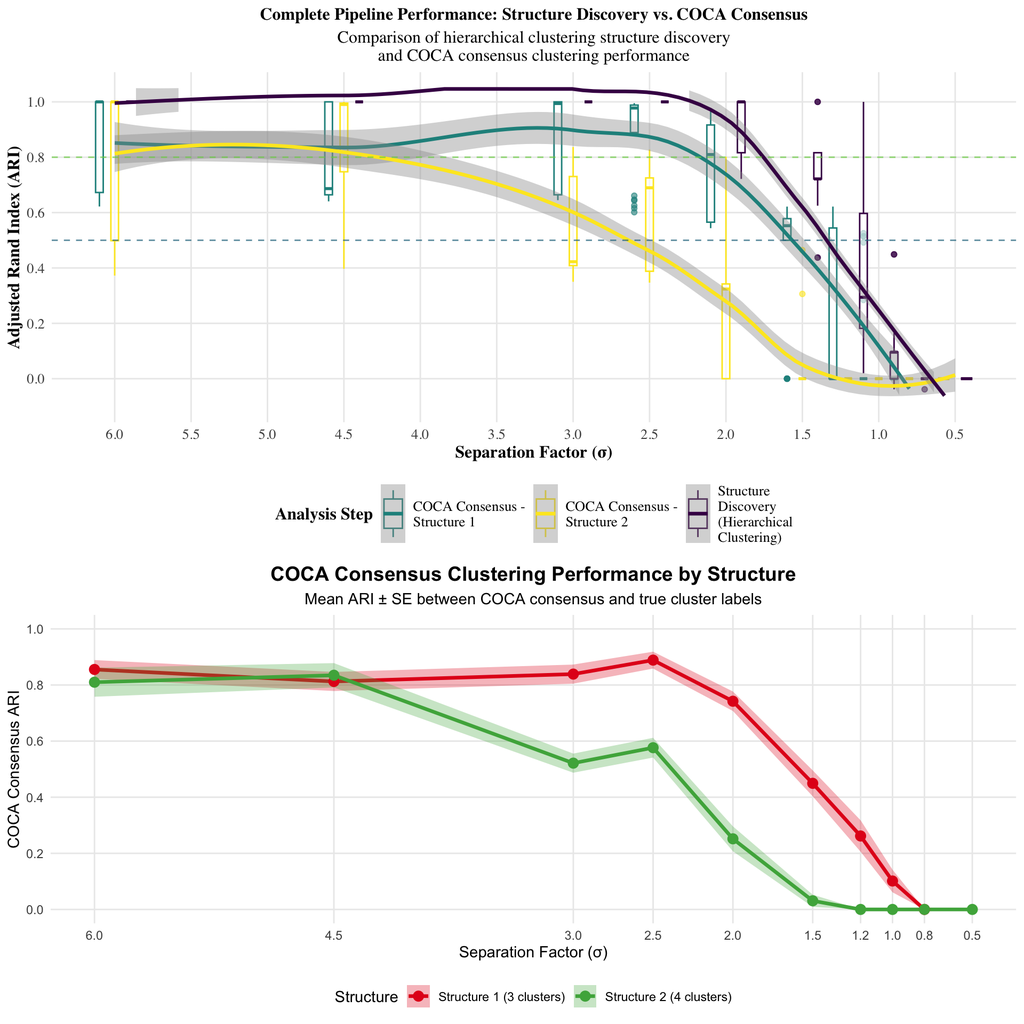

```r
p2 <- ggplot(coca_summary, aes(x = separation_factor)) +
  geom_line(aes(y = coca_s1_mean, color = "Structure 1 (3 clusters)"), size = 1.2) +
  geom_ribbon(aes(ymin = coca_s1_mean - coca_s1_se, ymax = coca_s1_mean + coca_s1_se,
                  fill = "Structure 1 (3 clusters)"), alpha = 0.3) +
  geom_line(aes(y = coca_s2_mean, color = "Structure 2 (4 clusters)"), size = 1.2) +
  geom_ribbon(aes(ymin = coca_s2_mean - coca_s2_se, ymax = coca_s2_mean + coca_s2_se,
                  fill = "Structure 2 (4 clusters)"), alpha = 0.3) +
  geom_point(aes(y = coca_s1_mean, color = "Structure 1 (3 clusters)"), size = 3) +
  geom_point(aes(y = coca_s2_mean, color = "Structure 2 (4 clusters)"), size = 3) +
  scale_x_reverse(breaks = separation_factors) +
  scale_y_continuous(limits = c(0, 1), breaks = seq(0, 1, by = 0.2)) +
  scale_color_manual(values = c("Structure 1 (3 clusters)" = "#E41A1C",
                               "Structure 2 (4 clusters)" = "#4DAF4A")) +
  scale_fill_manual(values = c("Structure 1 (3 clusters)" = "#E41A1C",
                              "Structure 2 (4 clusters)" = "#4DAF4A")) +
  labs(title = "COCA Consensus Clustering Performance by Structure",
       subtitle = "Mean ARI ± SE between COCA consensus and true cluster labels",
       x = "Separation Factor (σ)",
       y = "COCA Consensus ARI",
       color = "Structure", fill = "Structure") +
  theme_minimal() +
  theme(plot.title = element_text(hjust = 0.5, size = 14, face = "bold"),
        plot.subtitle = element_text(hjust = 0.5),
        legend.position = "bottom",
        panel.grid.minor = element_blank())

# Combine plots
grid.arrange(p1, p2, nrow = 2, heights = c(1.2, 1))
```

## 4.3 Critical Thresholds for Complete Pipeline

```r
cat("Enhanced Critical Separation Thresholds:\n")
```

```
## Enhanced Critical Separation Thresholds:
```

```r
cat("=========================================\n\n")
# Structure discovery thresholds
structure_80 <- enhanced_summary %>%
  filter(mean_ari >= 0.8) %>%
  summarise(min_separation = min(separation_factor)) %>%
  pull(min_separation)

structure_50 <- enhanced_summary %>%
  filter(mean_ari >= 0.5) %>%
  summarise(min_separation = min(separation_factor)) %>%
  pull(min_separation)

cat("Structure Discovery (HClust):\n")
```

```
## Structure Discovery (HClust):
```

```r
cat("- Reliable recovery (ARI ≥ 0.8):",
    ifelse(length(structure_80) > 0, paste("≥", structure_80, "σ"), "None"), "\n")
```

```
## - Reliable recovery (ARI ≥ 0.8): ≥ 2 σ
```

```r
cat("- Moderate recovery (ARI ≥ 0.5):",
    ifelse(length(structure_50) > 0, paste("≥", structure_50, "σ"), "None"), "\n\n")
```

```
## - Moderate recovery (ARI ≥ 0.5): ≥ 1.5 σ
```

```r
# COCA consensus thresholds
coca_s1_80 <- enhanced_summary %>%
  filter(mean_coca_ari_s1 >= 0.8) %>%
  summarise(min_separation = min(separation_factor)) %>%
  pull(min_separation)

coca_s1_50 <- enhanced_summary %>%
  filter(mean_coca_ari_s1 >= 0.5) %>%
  summarise(min_separation = min(separation_factor)) %>%
  pull(min_separation)

coca_s2_80 <- enhanced_summary %>%
  filter(mean_coca_ari_s2 >= 0.8) %>%
  summarise(min_separation = min(separation_factor)) %>%
  pull(min_separation)

coca_s2_50 <- enhanced_summary %>%
  filter(mean_coca_ari_s2 >= 0.5) %>%
  summarise(min_separation = min(separation_factor)) %>%
  pull(min_separation)

cat("COCA Consensus - Structure 1:\n")
```

```
## COCA Consensus - Structure 1:
```

```r
cat("- Reliable recovery (ARI ≥ 0.8):",
    ifelse(length(coca_s1_80) > 0, paste("≥", coca_s1_80, "σ"), "None"), "\n")
```

```
## - Reliable recovery (ARI ≥ 0.8): ≥ 2.5 σ
```

```r
cat("- Moderate recovery (ARI ≥ 0.5):",
    ifelse(length(coca_s1_50) > 0, paste("≥", coca_s1_50, "σ"), "None"), "\n\n")
```

```
## - Moderate recovery (ARI ≥ 0.5): ≥ 2 σ
```

```r
cat("COCA Consensus - Structure 2:\n")
```

```
## COCA Consensus - Structure 2:
```

```r
cat("- Reliable recovery (ARI ≥ 0.8):",
    ifelse(length(coca_s2_80) > 0, paste("≥", coca_s2_80, "σ"), "None"), "\n")
```

```
## - Reliable recovery (ARI ≥ 0.8): ≥ 4.5 σ
```

```r
cat("- Moderate recovery (ARI ≥ 0.5):",
    ifelse(length(coca_s2_50) > 0, paste("≥", coca_s2_50, "σ"), "None"), "\n\n")
```

```
## - Moderate recovery (ARI ≥ 0.5): ≥ 2.5 σ
```

```r
# Overall pipeline performance
combined_performance <- results_df %>%
  mutate(
    pipeline_success = (recovery_ari >= 0.8) &
                      (coca_ari_struct1 >= 0.8 | is.na(coca_ari_struct1)) &
                      (coca_ari_struct2 >= 0.8 | is.na(coca_ari_struct2))
  ) %>%
  group_by(separation_factor) %>%
  summarise(success_rate = mean(pipeline_success, na.rm = TRUE), .groups = 'drop')

pipeline_threshold <- combined_performance %>%
  filter(success_rate >= 0.8) %>%
  summarise(min_separation = min(separation_factor)) %>%
  pull(min_separation)

cat("Complete Pipeline (Structure Discovery + COCA Consensus):\n")
```

```
## Complete Pipeline (Structure Discovery + COCA Consensus):
```

```r
cat("- Reliable end-to-end performance (≥80% success):",
    ifelse(length(pipeline_threshold) > 0, paste("≥", pipeline_threshold, "σ"), "None"), "\n")
```

```
## - Reliable end-to-end performance (≥80% success): ≥ Inf σ
```

# 5. Conclusions

## Practical Implications

- **Method Validation**: This enhanced simulation provides comprehensive evidence for when the complete methodology is likely to succeed or fail
- **Parameter Guidance**: Results inform optimal separation requirements for reliable structure recovery and consensus clustering
- **Computational Considerations**: The caching approach demonstrates how to efficiently extend existing simulation studies without full re-computation

## Future Extensions

This enhanced framework enables testing of: - Alternative consensus clustering methods vs. COCA - Different MOC construction strategies  
- Varying consensus clustering parameters (B, pItem, etc.) - Computational performance analysis across separation levels

The complete simulation study now provides a thorough validation of both the structure discovery and consensus clustering components of the methodology.